# HW4

B02701143 工管四 林以理

2017年5月18日

# 紐約機場資料雙變數分析

## 載入2013年紐約機場資料

```r
library(dplyr)
library(nycflights13)
```

## 挑出1月1日的資料，對起飛時間、降落時間、起飛誤時、降落誤時做敘述統計分析

```r
flights <- filter(flights, month == 1, day == 1)
summary(flights[4:7])
```

```
##     dep_time        dep_delay         arr_time      arr_delay
##  Min.   : 517.0   Min.   :-15.00   Min.   :   3   Min.   :-48.00
##  1st Qu.: 940.2   1st Qu.: -4.00   1st Qu.:1152   1st Qu.: -8.00
##  Median :1439.5   Median : -1.00   Median :1633   Median :  3.00
##  Mean   :1385.0   Mean   : 11.55   Mean   :1562   Mean   : 12.65
##  3rd Qu.:1756.8   3rd Qu.:  9.00   3rd Qu.:2006   3rd Qu.: 19.00
##  Max.   :2356.0   Max.   :853.00   Max.   :2400   Max.   :851.00
##  NA's   :4        NA's   :4        NA's   :5      NA's   :11
```

起飛時間(dep_time)與降落時間(arr_time)為區間尺度，故不適合作平均的分析。 我們可以看到所有的起飛時間都在早上五點十七分之後，在二十三點五十六分結束所有的航程。 這天的飛機平均比預定時間晚11.55分鐘起飛，也同時比預定時間晚12.65分鐘降落，表示總航程時間比預定飛行時間 多出1.1分鐘。誤點起飛的第三四分位數與中位數均較平均數來的低，可以得知其平均可能受到一個極端值影響而拉高，中位數甚至比預定的還要早一分鐘起飛；反觀誤點抵達的分布則較正常，然而可以從第三四分位數與第一四分位數的距離得知，誤點抵達的變異較誤點出發的變異來的大，可以推估是因為在天上飛行的情況較難掌握，導致了降落時間較難預估。

## 抵達誤時會受飛行時間與距離影響嗎?

## 對抵達誤時、飛行時間、飛行距離做迴歸分析

```r
test <- lm(flights$arr_delay ~ flights$air_time + flights$distance)
summary(test)
```

```
##
## Call:
## lm(formula = flights$arr_delay ~ flights$air_time + flights$distance)
##
## Residuals:
##    Min     1Q Median     3Q    Max
## -50.42 -19.21 -10.44   3.99 841.38
##
## Coefficients:
##                  Estimate Std. Error t value Pr(>|t|)
## (Intercept)      -0.85275    4.04426  -0.211    0.833
## flights$air_time  0.68144    0.09376   7.268 8.46e-13 ***
## flights$distance -0.09494    0.01242  -7.642 5.90e-14 ***
## ---
## Signif. codes:  0 '***' 0.001 '**' 0.01 '*' 0.05 '.' 0.1 ' ' 1
##
## Residual standard error: 47.69 on 828 degrees of freedom
##   (11 observations deleted due to missingness)
## Multiple R-squared:  0.06781,    Adjusted R-squared:  0.06556
## F-statistic: 30.12 on 2 and 828 DF,  p-value: 2.369e-13
```

根據趨近於零的p-value，兩個變數均通過檢定，證實假設。 我發現每增加一分鐘的飛行時間，會造成多0.68分鐘的誤點；而每多一哩的里程，會提早約0.09分鐘到達目的地。

## 做誤點時間與不同航空公司的變異數分析

```r
anova(test2 <- lm(flights$arr_delay ~ flights$carrier))
```

```
## Analysis of Variance Table
##
## Response: flights$arr_delay
##                  Df  Sum Sq Mean Sq F value    Pr(>F)
## flights$carrier  13  194863   14989  6.7098 2.486e-12 ***
## Residuals       817 1825146    2234
## ---
## Signif. codes:  0 '***' 0.001 '**' 0.01 '*' 0.05 '.' 0.1 ' ' 1
```

通過檢定，證實抵達誤點時間會因為不同航空公司而有所不同。

## 根據航空公司分類，做誤點時間與飛行距離的圖解關係

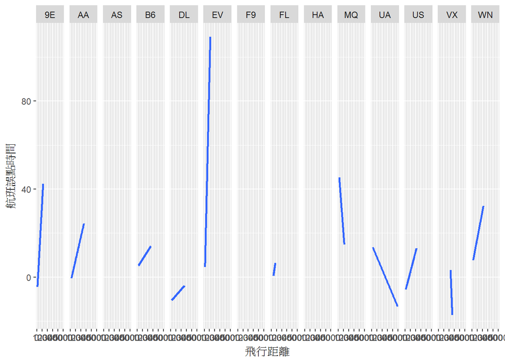

```r
library(ggplot2)
ggplot(data=flights, aes(group=carrier, y= arr_delay, x= distance))+
  stat_smooth(method = 'lm', se = F)+
  stat_smooth(aes(group=carrier, y= arr_delay, x= distance),method = 'lm', se = F)+
  facet_grid(.~carrier)+
  labs(x='飛行距離', y='航班誤點時間')
```

可以看到AA(American Airlines) B6(Jetblue Airway) DL(Delta Airlines) FL(AirTran Airways) UA(United Airlines) 都算是準時，其中DL都會比預估時間還要早到。9E(Endeavor Air) EV (ExpressJet Airlines) MQ(Envoy Air)的誤點情況較嚴重，有時會有極端值出現。UA(United Airlines)所涵蓋的飛行距離較廣，距離越長，比預計時間越早到。VX所負責的飛行距離較一致，固定飛中等航程的城市。